# 美债市场的运行机制解析

[figure not shown]

2024年，美国净利息支出达到8800亿美元，占联邦支出的13.1%，首次超过国防开支，成为政府的第三大支出项目。根据美国国会预算办公室（CBO）的最新预测，未来30年，美债利息支出将持续增长，到2055年将占联邦财政收入的28%.

这引发了市场对美国政府“**是否具备足够财政收入覆盖利息支出**”的深刻担忧。三大国际评级机构先后下调了美国主权信用评级，特斯拉CEO埃隆·马斯克也曾多次抨击“大而美”减税计划，并警示美国正面临债务危机。

为更系统地理解美债当前所面临的结构性风险与未来可能走向，本文将从三方面展开分析：一是美债市场的三类关键参与者及其作用机制；二是美债收益率的核心决定因素及其市场传导逻辑；三是近年来影响美债市场的重要事件与政策演变。希望借此帮助大家构建对美债市场的清晰认识。

## 一、美债市场的三类参与者

美债市场的运行机制可以从三个关键参与者的角度来理解：财政部、联邦储备系统（美联储）、以及市场投资者。这三者共同构成了美债市场的供给、调控与定价体系。

[figure not shown]

### 1. 财政部：一级市场的供给方

财政部代表联邦政府，负责制定财政政策和管理国家财政。当政府出现财政赤字，即财政收入小于支出时，财政部需要通过发行国债来融资，以维持政府日常运转与支出安排。财政部决定了国债的发行时间、规模与期限结构，从而构成了美债市场的主要供给来源。

### 2. 美联储：二级市场的调控者

美联储作为美国的中央银行，拥有**独立的货币政策**制定权，其最高决策机构是FOMC（联邦公开市场委员会）。美联储通过多种货币政策工具，直接或间接地影响美债的收益率曲线：

- **短期利率**：通过**公开市场操作**调整联邦基金利率，影响短端收益率。
  - **回购**  
    美联储买入证券，并约定未来卖回，向市场**注入短期流动性，降低短期利率**，通常在*经济低迷、就业不振*时使用。
  - **逆回购**  
    美联储卖出证券，并约定未来买回，从市场**回收流动性，提升短期利率**，用于*应对通胀和经济过热*。
  - TIPS：*中美央行的正逆回购方向相反*，如美联储逆回购是收走流动性，而中国人民银行逆回购是释放流动性。
- **长期利率**：在传统政策空间受限（如利率接近零）时，采用**非常规手段**来调整市场流动性与利率预期。
  - **量化宽松（QE）**：大规模购买长期国债，压低长期利率，增加市场流动性。

[figure not shown]

  - **量化紧缩（QT）**：减少美联储资产负债表规模，回收流动性，推升长期利率。
- **财政部与美联储的矛盾**

**政策目标冲突**

- **财政部：降债务成本**  
  财政部需低成本融资以维持政府运转，37万亿美元债务的日息支出超20亿美元，迫切要求降息减轻负担。
- **美联储：控通胀**  
  美联储需维持物价稳定（通胀目标2%）和充分就业，当前高通胀环境下必须维持高利率以压制需求。

**债务管理策略冲突**

- **财政部：短债优先，借短还长**  
  为快速填补1万亿美元国库账户（TGA）缺口，财政部在2025年7月宣布大量发行短期国债，因其流动性强、发行速度快。
- **美联储：长期稳定**  
  短债具备“准货币”属性，大量发行相当于变相增加市场美元流动性，可能抵消美联储缩表（QT）效果，加剧通胀。

### 3. 市场：二级市场的定价者

二级市场上的投资者，包括商业银行、保险公司、对冲基金、国际资本等，是美债价格的直接决定者。他们依据对未来利率、通胀、经济、政治等因素的判断，进行买卖操作。市场的供需关系与风险偏好反映在价格波动中，从而影响美债的收益率。

例如，当经济衰退风险上升时，投资者可能买入美债以避险，推高价格、压低收益率；而当通胀预期上升、外资减持、或财政赤字扩大时，投资者可能要求更高的收益率，推动价格下跌。

## 二、美债收益率的定价逻辑

理解美债收益率的变化，不仅需要掌握市场操作的参与者机制，还要掌握其核心定价框架。前美联储主席伯南克曾提出，长期美债收益率主要由三个因素决定： 未来短期实际利率 + 通胀预期 + 期限溢价。

这一理论模型提供了分析收益率变动的基础结构。以下将分别解释每一项因素，并结合实际政策与市场行为说明其背后逻辑。

### 1. 未来短期实际利率：由美联储调控引导

“未来短期实际利率”指的是剔除通胀后的联邦基金利率预期，是收益率曲线的核心锚点。它由美联储通过货币政策主动引导。

- **政策传导机制**  
  美联储通过加息/降息、前瞻指引和点阵图等方式，影响市场对未来短期利率的预期。
- **市场反应机制**  
  若市场预期未来将持续加息，则长期收益率会随之上升；反之，则下降。
- 举例说明  
  在2022年高通胀背景下，美联储连续激进加息，使市场预期短期利率将长时间维持高位，导致长期美债收益率显著上行。

### 2. 通胀预期：影响名义收益率的补偿要求

通胀预期反映投资者对未来物价水平的判断，是名义收益率中补偿“货币购买力贬值”的一部分。

- **市场定价机制**  
  通胀预期上升意味着实际利率不变时，投资者会要求更高的名义利率作为补偿，推动债券价格下跌、收益率上升。

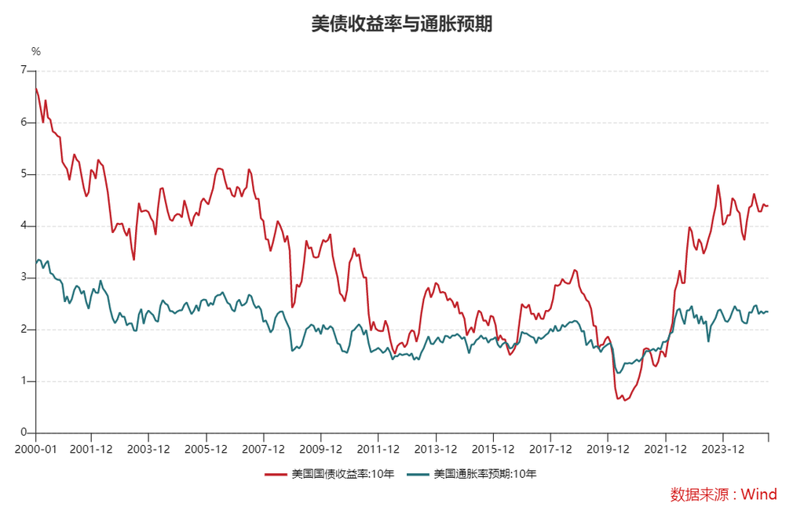

- **期限敏感性差异**  
  长期债券对通胀的敏感度更高，因为投资期限越长，通胀不确定性越大。
- 举例说明  
  2021年–2022年，美国CPI持续高企，导致通胀预期飙升，推动长期美债收益率快速上行。

### 3. 期限溢价：反映市场的不确定性补偿

期限溢价是长期国债对不确定性的额外补偿，即投资者愿意持有期限更长的资产所要求的“额外收益”。 影响期限溢价的因素主要包括：

- **经济不确定性**  
  如经济下行风险加剧时，避险情绪上升，投资者更青睐美债，收益率下降。
- **财政风险**  
  当市场对美国财政状况（如债务水平、赤字规模）感到担忧时，会要求更高的收益率进行补偿。
- **地缘政治风险**  
  例如战争、全球金融不稳定等，可能刺激避险需求或资本回流美国，影响期限溢价方向。
- 举例说明：2023年后，美国财政赤字扩大、政府关门风险频发、信用评级被下调，都显著提升了期限溢价，推动长期美债收益率上行。

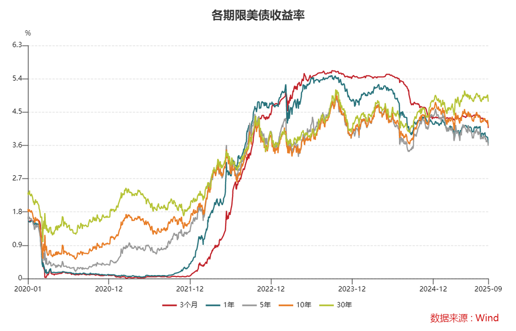

如上图所示，各期限的收益率之差即可视为期限溢价。

综上，长期美债收益率的波动，是政策预期（由美联储主导）+通胀走势（由宏观环境决定）+不确定性溢价（由市场风险偏好驱动）共同作用的结果。这一结构化理解框架，能够帮助我们更清晰地解读实际中的美债价格变动。

## 三、近年美债市场的三次重大冲击

### 1. 2020年新冠疫情爆发：极端冲击下的财政货币联手干预

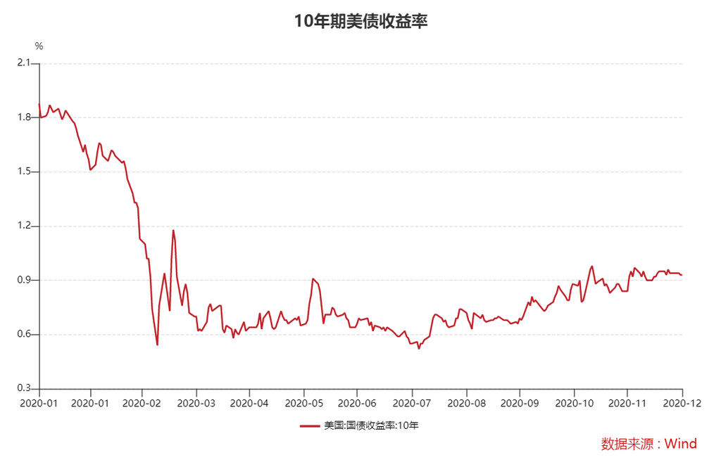

**① 背景：疫情打击实体经济，美债需求骤然上升**  
2020年初新冠疫情迅速蔓延，美国经济活动陷入停摆，失业率在短时间内飙升至近15%，企业与居民现金流紧张，消费与投资骤降。市场恐慌蔓延，引发资产价格剧烈下跌，全球资本涌向美债等避险资产，短期内美债收益率快速下探。

**② 政策响应：财政部大规模发债支出，美联储无限宽松托底**  
为防止经济坠入衰退深渊，财政部推出总规模数万亿美元的紧急刺激计划，包括现金补贴、失业救济扩张、企业纾困贷款等。这直接带来国债发行规模的激增。  
与此同时，美联储迅速将联邦基金利率下调至零，并启动了无限量化宽松政策，持续购买美债和MBS，维持市场流动性。这些操作有效地降低了全市场融资成本，防止信贷冻结，稳定了银行体系与资本市场。

**④ 后续影响：为未来通胀积蓄势能**  
虽然短期成功稳定了市场，但大规模货币与财政扩张，也埋下了未来通胀与资产泡沫的伏笔。此后两年，随着供应链受限与需求过剩叠加，美国进入新一轮通胀周期，为2022年的政策转向埋下伏笔。

### 2. 2022年通胀失控：急速加息下的市场应激

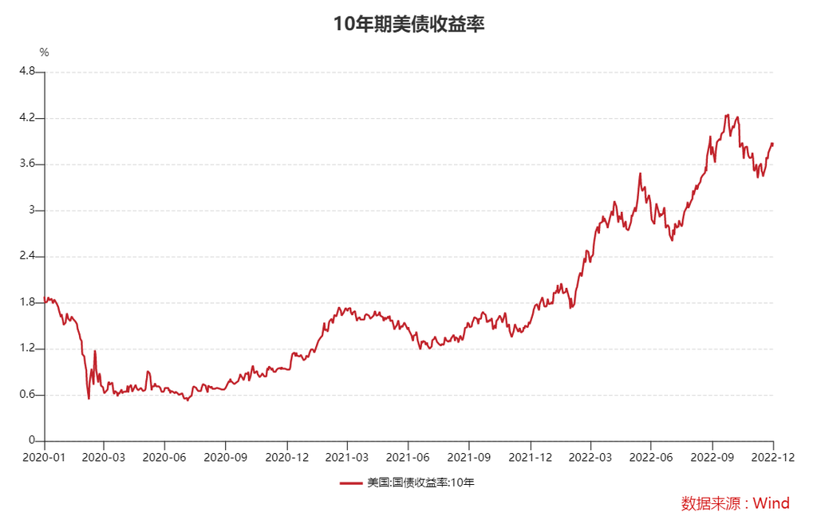

**① 背景：通胀飙升，美联储政策转向**  
在2021–2022年，美国经济从疫情中快速复苏，叠加供应链瓶颈与能源价格上涨，消费需求回暖而供给受限，推动物价全面上行。到2022年中，美国PCE（个人消费支出物价指数）同比涨幅超过7%，创40年新高，远高于美联储设定的2%通胀目标。  
在通胀失控的压力下，美联储政策立场迅速转变，摆脱2020–2021年“通胀是暂时的”论调，从2022年3月开始进入加息周期，共进行了11次加息，幅度从最开始的25个基点，到后来的50个基点，并于随后数月内连续4数次大幅加息75个基点，开启“历史最快加息周期”。

**② 加息效应：收益率曲线倒挂**  
随着美联储大幅上调短端政策利率，短期美债收益率迅速上升。然而，由于市场预期高利率将导致经济放缓，长期利率上行空间有限，导致收益率曲线倒挂（短期收益率高于长期收益率）。  
这是市场对未来经济衰退预期的反映，也显著改变了金融机构的风险暴露结构。

**③ 外部变动：国际资金结构转向，美债边际需求疲弱**

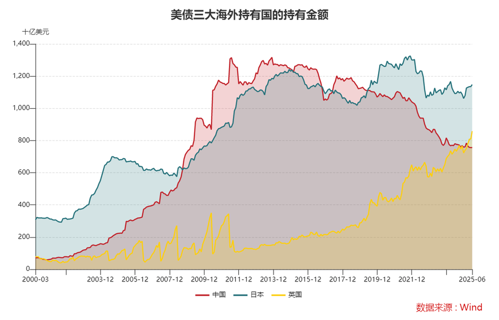

**④ 风险暴露：硅谷银行倒闭引发系统性担忧**  
2023年3月，硅谷银行（SVB）宣布破产，成为加息周期中首家倒下的金融机构。硅谷银行拥有大量持有至到期的长期固定利率美债，但在加息背景下，这些资产市场价值大幅缩水。与此同时，负债端的存款客户因货币市场利率更高而快速撤资，银行遭遇流动性挤兑，最终引发连锁危机。  
硅谷银行事件暴露出：在利率迅速上升的环境下，银行资产久期错配风险上升，尤其是持有大量美债的机构，面临估值与流动性的双重压力。

**⑤ 政策救市：美联储稳定信心，避免进一步传染**  
面对金融动荡风险，美联储迅速推出银行定期融资计划（BTFP），允许银行以“票面价值”质押美债和MBS换取流动性，从而避免“被迫出售”引发更多损失。这一计划实质上为美债市场注入了稳定机制，也缓解了银行因利率波动面临的资产折价风险。  
在硅谷银行事件后，美联储虽然依旧坚持加息抗通胀的政策基调，但开始在金融系统稳定与货币紧缩之间寻求更谨慎的平衡。

### 3. 2025年政策与市场冲击：多重因素撼动美债“无风险”地位

**① 背景：关税政策突变引发避险失灵**  
2025年4月，美国政府宣布对包括中国、德国、日本等在内的主要贸易国实施“对等关税”政策，最高税率达245%。该政策被广泛视为贸易保护主义升级，市场担忧关税可能推升物价、压制经济增长，形成“滞胀”格局。避险情绪并未带来美债上涨，反而出现“股债汇三杀”：投资者同时抛售美股、美债与美元，金融市场剧烈震荡。  
其中，10年期美债收益率在一周内上涨近50个基点至4.6%，30年期收益率突破5%，创下40年来最大单周涨幅。市场不再将美债视作稳定的避险资产，而开始重新评估其长期财政与政策不确定性风险，期限溢价显著上升，收益率曲线整体抬升。

**③ 三大评级机构集体降级美国国债**  
继标准普尔在2011年下调美国主权信用评级后，惠誉于2023年8月、穆迪于2025年5月相继跟进，将美国评级下调至AA+或以下。至此，三大国际评级机构均不再给予美国最高评级。评级机构普遍指出，美国债务与利息负担持续上升、财政赤字高企、预算僵局与债务上限危机频发，已严重削弱财政治理能力。尽管短期内未引发系统性危机，但降级对保险、养老金等制度型投资者构成配置约束，也进一步动摇了市场对美债作为“无风险资产”的信心。

## 四、未来展望

美债不仅是美国政府的融资工具，更是全球美元体系的“**信用锚点**”。长期以来，美国通过“美元循环”构建出独特的全球收支结构：一方面，美国在全球范围内以美元计价进口商品与服务；另一方面，顺差国家积累的美元储备反过来配置至美债市场，为美国财政赤字提供融资支持。这一“**出口美元—回流美债**”的循环机制，使得**美债成为支撑美元霸权、金融稳定和全球流动性的三重支柱**。

近年来，随着数字金融技术的发展，**稳定币**正成为美元霸权的“链上延伸”。从挂钩机制来看，全球83%的稳定币选择挂钩美元，形成“数字美元”的跨境流通网络，将美元信用从传统支付体系延伸至区块链世界。自2020年以来，稳定币总市值从200亿美元飙升至2025年的约2500亿美元，间接带动了近2000亿美元的短期美债需求。在此过程中，**稳定币发行商实际上扮演了“新型央行”的角色**：当市场流入资金、稳定币扩张时，发行方需同步增持短债维稳币价，推动短期美债价格上行、收益率下行；而*当资金流出或市场恐慌出现时，稳定币面临兑付压力，被迫抛售美债，从而引发债市波动*。

更深层次的问题在于，这类“链上美元”既依赖法币本身的信用支撑，也依赖美债的资产信用，而两者均建立在美国财政可持续性的预期之上。若美债信用动摇，链式反应将迅速从链下金融市场传导至链上世界。一旦出现稳定币脱锚或挤兑，极易与美债抛售形成负反馈回路，削弱其“避险资产”的市场信仰，进而动摇全球资金配置体系的基石。

在此背景下，未来美债市场可能面临以下几类系统性冲击：

1. **财政失衡与债务供给失控**  
   2025年Q3美国财政部计划净发行约1万亿美元的国债，创历史同期新高。若债券供给远超市场承接能力，拍卖认购乏力，或将引发收益率陡升、价格快速下跌，进而抬高全市场融资成本，诱发连锁反应。
2. **稳定币立法推动短债集中配置，放大脆弱性**  
   GENIUS法案要求100%准备金制度，并限定储备资产为美元现金与短期美债，这在短期可强化短债需求、降低融资压力。但一旦面临流动性冲击，集中配置短债也会加剧赎回压力与资产流动性风险，对短端市场构成扰动。
3. **关税政策、货币政策与通胀预期错位**  
   当前市场对美联储9月降息的预期升温，但通胀前景仍存在不确定性。特朗普政府在上半年的关税政策可能对通胀产生持久影响。6月CPI数据显示，进口商品成本已开始向终端消费传导，后续的关税政策可能会进一步加剧通胀的粘性风险。若CPI与PPI数据持续高于预期，将迫使美联储延后降息甚至再次加息。长端美债收益率可能再度陡峭化上行，扰乱资产定价体系，再次引发高杠杆策略（如基差交易）爆仓风险。
4. **地缘政治加剧“去美元化”进程**  
   近年来，全球主要经济体（如中国、俄罗斯、部分中东国家）已逐步推进本币结算、去美元化储备配置，减少对美债的依赖。2022年起中国和日本双双减持美债已敲响警钟。若地缘摩擦进一步升级，可能诱发主权资金“非市场化”大规模撤离，形成外资对美债需求塌方。

从全球资金配置角度看，美债依然是体量最大、市场最深、流动性最强的信用资产，但其“无风险”神话正在被不断挑战。未来任何冲击美元信用锚点的事件，不论来自财政、金融还是技术领域，都会在美债市场留下回响。唯有重构可持续的财政纪律、稳定的货币预期与多元的投资者结构，美债市场才能穿越未来更具不确定性的周期浪潮。